# Three bars setup study

Andrea Nalon

6 November 2015

This document will test one of the best known pettern: the 3 bars reversal setup. In particular the pattern is searched for intraday bars and if a setup is found, a BUY order is triggered. **Only long trades are covered in this study, not shorts.**

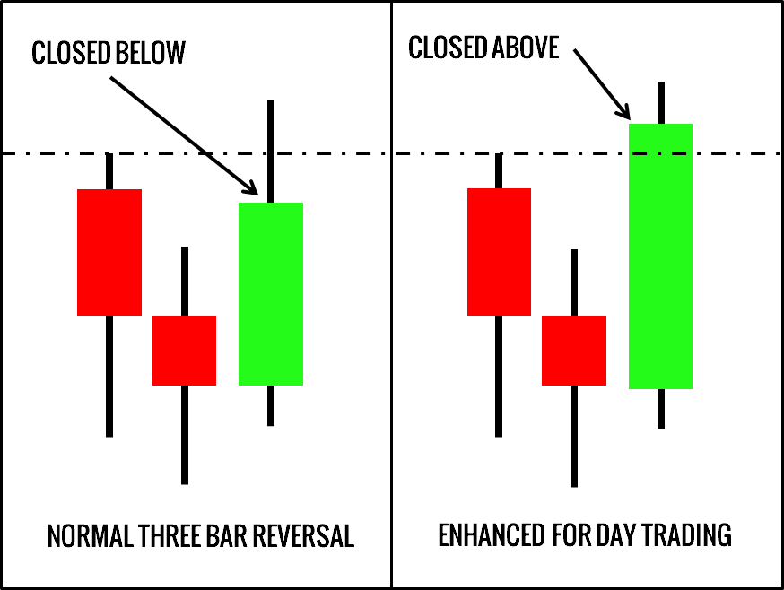

**RULES FOR LONG**  
1. Bar 1 closes down  
2. Low of Bar 2 is below low of Bar 1 (and Bar 3)  
3. High of Bar 2 is below high of Bar 1  
4. Bar 3 closes above the high of both Bar 1 and Bar 2  
5. Buy at close of Bar 3

### The asset used for the simulation is the SP&500 index future, with 5 minutes bars.

*All the simulations include a slippage of 0.6 + 0.6 = 1.2 basis points for each roundturn (open - close trade).*

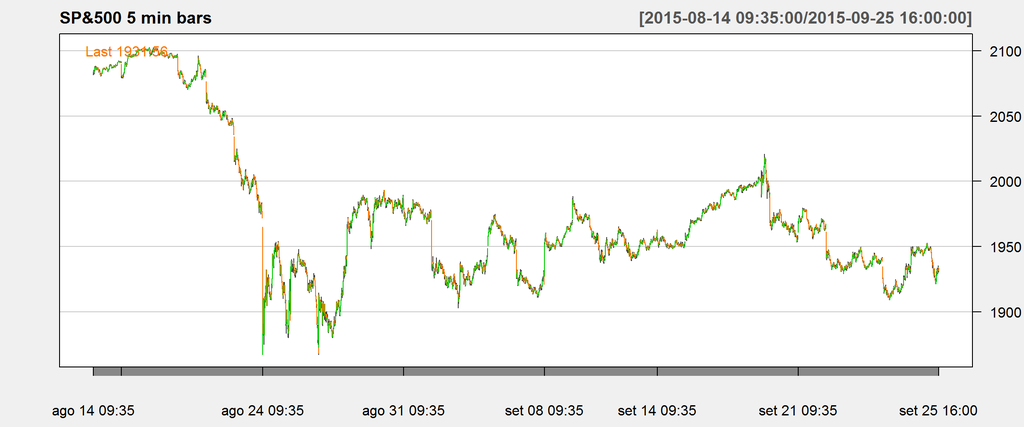

## Simulation 1.

Each trade is managed with a trailing stop set to the previous low. The slippage for each roundturn is 0 points.

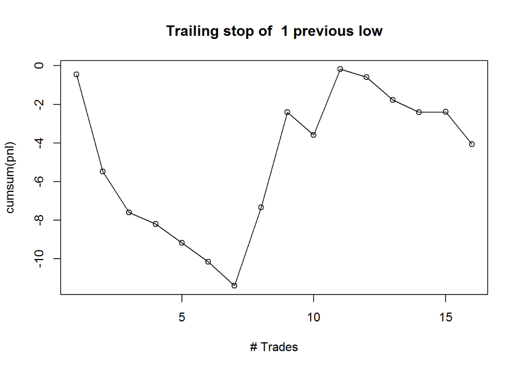

## Simulation 2.

Each trade is managed with a stop level, set upon the volatility of the last 68 bars. The slippage for each roundturn is 0 points.

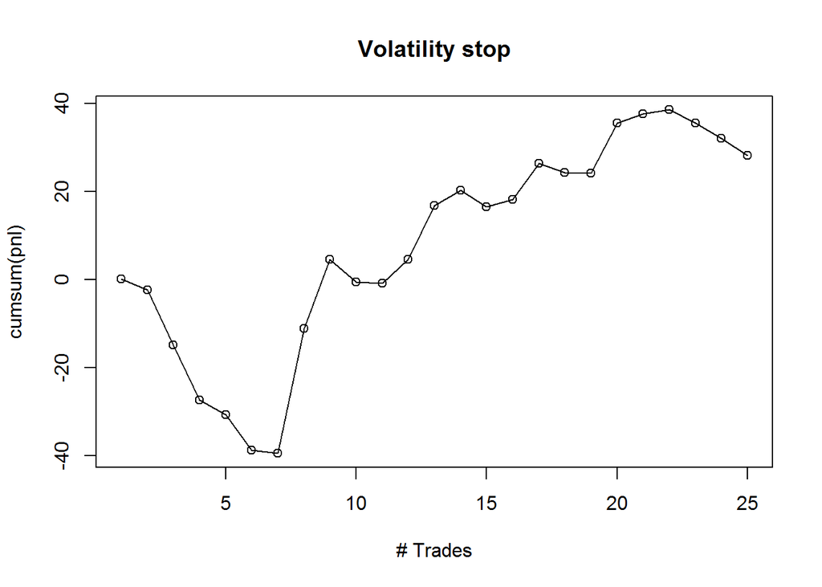

## Simulation 3.

Each trade is managed with a fixed stop level of -3 points. The slippage for each roundturn is 0 points.

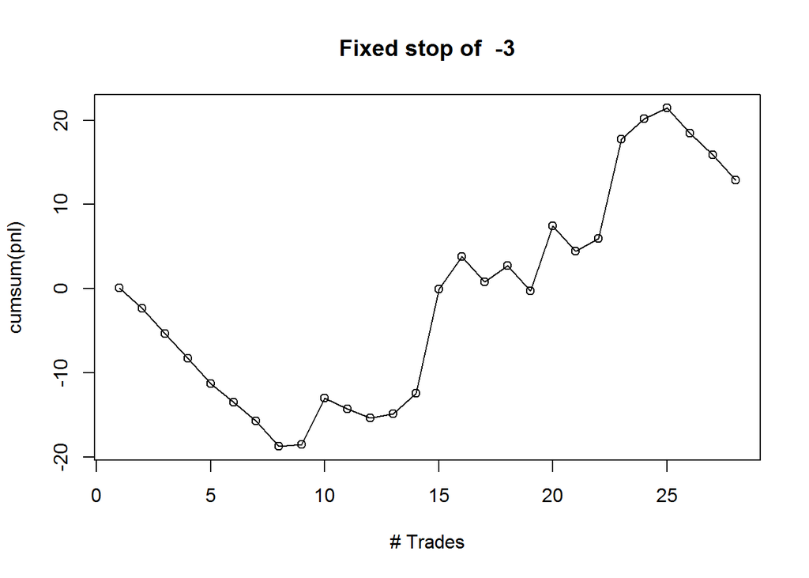